# TEMA 3: DIAGNOSIS, CORRECCIONES Y/O EXTENSIONES DEL MRL

Aplicación 3.12 (Variable dependiente discreta -> modelos Logit y Probit): Elección entre tipo de interés fijo o variable

Julián Ramajo, ramajo@unex.es

GRADO EN ESTADÍSTICA | ECONOMETRIA (502243)

# Introducción

En un artículo del año 1987, Dhillon y otros autores estudiaron el conjunto de características personales y financieras que determinan la elección por parte de los individuos de un tipo de interés fijo frente a uno variable a la hora de contratar un préstamo hipotecario. El interés de su trabajo radicaba en contrastar las dos posturas que dominan los planteamientos teóricos sobre el tema: la primera de ellas opina que, de acuerdo con la **hipótesis de mercados eficientes**, las características personales del prestatario no contienen información que no haya sido ya tenida en cuenta por el mercado a la hora de fijar el tipo de interés y, por tanto, sólo las variables de precios y los términos del contrato serían relevantes cuando un individuo elige el tipo de interés que se le aplicará; la segunda escuela de pensamiento supone que existe **información asimétrica**, es decir, dadas las condiciones del mercado, los prestatarios pueden favorecerse no revelando algunas de sus características personales a la hora de firmar el contrato.

El modelo propuesto relaciona la probabilidad de que un individuo elija, dadas sus características personales y las condiciones del mercado, un tipo de interés variable frente a uno fijo para un préstamo hipotecario. Se dispone de una muestra de 78 clientes de un banco hipotecario norteamericano. Del total de observaciones, 46 eligieron un tipo de interés fijo (con vencimiento de 30 años) y 32 un tipo de interés variable (no acotado).

Las variables disponibles para estimar el modelo son las siguientes:

- Variable dependiente: *Y* toma el valor 1 si el individuo elige un tipo de interés variable y 0 si firma el préstamo a un tipo fijo.
- Variables explicativas del mercado: *FI* es el tipo de interés fijo que ofertó el banco, *MARG* el margen del tipo fijo sobre el tipo de interés variable, *YLD* la diferencia entre el tipo de interés de las letras del tesoro a 10 años y el tipo de las letras a 1 año (esta variable intenta anticipar el cambio futuro en los tipos de interés a corto plazo), *PTS* la ratio entre el tipo de interés fijo y el variable, y *MAT* la ratio entre los vencimientos de los préstamos hipotecarios con tipo fijo y variable.
- Variables explicativas personales: *BA* es la edad del prestatario, *BS* los años de escolarización, *FTB* una variable ficticia que toma el valor 1 si el prestatario compra vivienda por primera vez y 0 en otro caso, *CB* una ficticia que toma el valor 1 si existe un co-prestatario y 0 en otro caso, *MC* una ficticia que toma el valor 1 si el prestatario está casado y 0 si no lo está, *SE* una ficticia que toma el valor 1 si trabaja por cuenta propia y 0 en otro caso, *MOB* el número de años que el prestatario lleva residiendo en la dirección actual, *NW* la riqueza neta, *LA* los activos líquidos y *STL* los compromisos económicos del prestatario a corto plazo.

El modelo econométrico general que se estimará tiene la siguiente expresión:

$$Y_{i} = \beta_1 + \beta_2 FI_{i} +
\beta_3 MARG_{i} + \beta_4 YLD_{i} + \beta_5 PTS_{i} + \beta_6 MAT_{i} +
\beta_7 BA_{i} + \beta_8 BS_{i} + \beta_9 FTB_{i} + \beta_{10} CB_{i} +
...$$
$$... + \beta_{11} MC_{i} +
\beta_{12} MC_{i} + \beta_{13} SE_{i} + \beta_{14} MOB_{i} + \beta_{15}
NW_{i} + \beta_{16} LA_{i} + \beta_{17} ST_{i} + e_{i}$$

# Código R

```r
# Lectura de librerías
library(tidyverse)
library(AER)
library(alr4)
library(margins)
# Lectura de datos
PREST_HIP <- read_csv("PREST_HIP.csv")
summary(PREST_HIP)
```

```
##        BA              BS              CB              FI
##  Min.   :24.00   Min.   : 6.00   Min.   :0.000   Min.   :11.76
##  1st Qu.:31.00   1st Qu.:14.00   1st Qu.:0.000   1st Qu.:12.50
##  Median :36.50   Median :16.00   Median :0.000   Median :13.50
##  Mean   :36.04   Mean   :16.45   Mean   :0.359   Mean   :13.25
##  3rd Qu.:40.50   3rd Qu.:18.00   3rd Qu.:1.000   3rd Qu.:13.75
##  Max.   :65.00   Max.   :25.00   Max.   :1.000   Max.   :14.50
##       FTB               LA               MARG             MAT
##  Min.   :0.0000   Min.   : 0.0000   Min.   :-0.900   Min.   :0.420
##  1st Qu.:0.0000   1st Qu.: 0.6675   1st Qu.: 1.500   1st Qu.:0.930
##  Median :1.0000   Median : 1.3550   Median : 2.400   Median :1.000
##  Mean   :0.6154   Mean   : 5.6827   Mean   : 2.292   Mean   :1.058
##  3rd Qu.:1.0000   3rd Qu.: 8.9100   3rd Qu.: 3.040   3rd Qu.:1.000
##  Max.   :1.0000   Max.   :93.4900   Max.   : 5.500   Max.   :2.380
##        MC              MOB               NW               PTS
##  Min.   :0.0000   Min.   : 1.000   Min.   :-0.0560   Min.   :0.000
##  1st Qu.:0.0000   1st Qu.: 1.000   1st Qu.: 0.3585   1st Qu.:1.000
##  Median :1.0000   Median : 2.000   Median : 0.7945   Median :1.660
##  Mean   :0.6026   Mean   : 4.205   Mean   : 3.5040   Mean   :1.498
##  3rd Qu.:1.0000   3rd Qu.: 4.000   3rd Qu.: 7.5575   3rd Qu.:2.022
##  Max.   :1.0000   Max.   :28.000   Max.   :17.8600   Max.   :4.340
##        SE              STL              Y               YLD
##  Min.   :0.0000   Min.   : 0.00   Min.   :0.0000   Min.   :1.380
##  1st Qu.:0.0000   1st Qu.: 3.69   1st Qu.:0.0000   1st Qu.:1.450
##  Median :0.0000   Median : 8.44   Median :0.0000   Median :1.590
##  Mean   :0.1026   Mean   :13.42   Mean   :0.4103   Mean   :1.606
##  3rd Qu.:0.0000   3rd Qu.:19.43   3rd Qu.:1.0000   3rd Qu.:1.640
##  Max.   :1.0000   Max.   :86.35   Max.   :1.0000   Max.   :2.040
```

```r
# Modelo logit
modelo_logit <- glm(Y ~ FI + MARG + YLD + PTS + MAT + BA + BS + FTB + CB + MC + SE + MOB + NW + LA + STL, data=PREST_HIP, family=binomial(link="logit"))
summary(modelo_logit)
```

```
##
## Call:
## glm(formula = Y ~ FI + MARG + YLD + PTS + MAT + BA + BS + FTB +
##     CB + MC + SE + MOB + NW + LA + STL, family = binomial(link = "logit"),
##     data = PREST_HIP)
##
## Deviance Residuals:
##     Min       1Q   Median       3Q      Max
## -2.1639  -0.4782  -0.1384   0.6414   2.1456
##
## Coefficients:
##             Estimate Std. Error z value Pr(>|z|)
## (Intercept) -4.23887   10.47904  -0.405   0.6858
## FI           1.71750    0.72773   2.360   0.0183 *
## MARG        -1.18952    0.48545  -2.450   0.0143 *
## YLD         -4.62670    2.91972  -1.585   0.1130
## PTS         -1.49980    0.71993  -2.083   0.0372 *
## MAT         -2.05707    1.63112  -1.261   0.2073
## BA          -0.01048    0.07569  -0.138   0.8899
## BS          -0.19825    0.17245  -1.150   0.2503
## FTB          0.11092    0.98371   0.113   0.9102
## CB          -1.75974    1.24217  -1.417   0.1566
## MC          -1.92294    1.18297  -1.626   0.1041
## SE          -2.20851    2.80100  -0.788   0.4304
## MOB         -0.15308    0.09700  -1.578   0.1145
## NW           0.24406    0.18503   1.319   0.1872
## LA           0.02207    0.06101   0.362   0.7176
## STL          0.03156    0.05172   0.610   0.5417
## ---
## Signif. codes:  0 '***' 0.001 '**' 0.01 '*' 0.05 '.' 0.1 ' ' 1
##
## (Dispersion parameter for binomial family taken to be 1)
##
##     Null deviance: 105.604  on 77  degrees of freedom
## Residual deviance:  61.792  on 62  degrees of freedom
## AIC: 93.792
##
## Number of Fisher Scoring iterations: 6
```

```r
# Modelo probit
modelo_probit <- glm(Y ~ FI + MARG + YLD + PTS + MAT + BA + BS + FTB + CB + MC + SE + MOB + NW + LA + STL, data=PREST_HIP, family=binomial(link="probit"))
summary(modelo_probit)
```

```
##
## Call:
## glm(formula = Y ~ FI + MARG + YLD + PTS + MAT + BA + BS + FTB +
##     CB + MC + SE + MOB + NW + LA + STL, family = binomial(link = "probit"),
##     data = PREST_HIP)
##
## Deviance Residuals:
##      Min        1Q    Median        3Q       Max
## -2.08188  -0.49604  -0.07784   0.64347   2.08997
##
## Coefficients:
##              Estimate Std. Error z value Pr(>|z|)
## (Intercept) -3.107496   5.877216  -0.529   0.5970
## FI           1.008059   0.410667   2.455   0.0141 *
## MARG        -0.705235   0.272291  -2.590   0.0096 **
## YLD         -2.525164   1.588075  -1.590   0.1118
## PTS         -0.830267   0.397719  -2.088   0.0368 *
## MAT         -1.164395   0.894643  -1.302   0.1931
## BA          -0.003978   0.042864  -0.093   0.9261
## BS          -0.108266   0.099792  -1.085   0.2780
## FTB          0.143454   0.558299   0.257   0.7972
## CB          -1.066544   0.692153  -1.541   0.1233
## MC          -1.058573   0.672743  -1.574   0.1156
## SE          -1.127484   1.559724  -0.723   0.4698
## MOB         -0.093035   0.054982  -1.692   0.0906 .
## NW           0.128775   0.105279   1.223   0.2213
## LA           0.014615   0.034992   0.418   0.6762
## STL          0.016129   0.028296   0.570   0.5687
## ---
## Signif. codes:  0 '***' 0.001 '**' 0.01 '*' 0.05 '.' 0.1 ' ' 1
##
## (Dispersion parameter for binomial family taken to be 1)
##
##     Null deviance: 105.604  on 77  degrees of freedom
## Residual deviance:  61.459  on 62  degrees of freedom
## AIC: 93.459
##
## Number of Fisher Scoring iterations: 7
```

```r
# Significación de las características personales
linearHypothesis ( modelo_logit , c("BA = 0", "BS = 0","FTB = 0","CB = 0","MC = 0","SE = 0","MOB = 0","NW = 0","LA = 0","STL = 0"))
```

```
## Linear hypothesis test
##
## Hypothesis:
## BA = 0
## BS = 0
## FTB = 0
## CB = 0
## MC = 0
## SE = 0
## MOB = 0
## NW = 0
## LA = 0
## STL = 0
##
## Model 1: restricted model
## Model 2: Y ~ FI + MARG + YLD + PTS + MAT + BA + BS + FTB + CB + MC + SE +
##     MOB + NW + LA + STL
##
##   Res.Df Df  Chisq Pr(>Chisq)
## 1     72
## 2     62 10 12.728     0.2393
```

```r
# Modelos logit restringidos
modelo_logit_1 <- glm(Y ~ FI + MARG + YLD + PTS + MAT, data=PREST_HIP, family=binomial(link="logit"))
summary(modelo_logit_1)
```

```
##
## Call:
## glm(formula = Y ~ FI + MARG + YLD + PTS + MAT, family = binomial(link = "logit"),
##     data = PREST_HIP)
##
## Deviance Residuals:
##     Min       1Q   Median       3Q      Max
## -2.1131  -0.8118  -0.4449   0.9597   2.4977
##
## Coefficients:
##             Estimate Std. Error z value Pr(>|z|)
## (Intercept)  -6.7318     7.0594  -0.954  0.34029
## FI            1.2646     0.4540   2.785  0.00535 **
## MARG         -0.7178     0.3138  -2.287  0.02218 *
## YLD          -4.8275     1.9588  -2.465  0.01372 *
## PTS          -0.3590     0.4234  -0.848  0.39641
## MAT          -0.5503     1.0366  -0.531  0.59549
## ---
## Signif. codes:  0 '***' 0.001 '**' 0.01 '*' 0.05 '.' 0.1 ' ' 1
##
## (Dispersion parameter for binomial family taken to be 1)
##
##     Null deviance: 105.604  on 77  degrees of freedom
## Residual deviance:  82.946  on 72  degrees of freedom
## AIC: 94.946
##
## Number of Fisher Scoring iterations: 4
```

```r
linearHypothesis ( modelo_logit_1, c("PTS = 0", "MAT = 0"))
```

```
## Linear hypothesis test
##
## Hypothesis:
## PTS = 0
## MAT = 0
##
## Model 1: restricted model
## Model 2: Y ~ FI + MARG + YLD + PTS + MAT
##
##   Res.Df Df Chisq Pr(>Chisq)
## 1     74
## 2     72  2 0.959     0.6191
```

```r
#
modelo_logit_2 <- glm(Y ~ FI + MARG + YLD, data=PREST_HIP, family=binomial(link="logit"))
summary(modelo_logit_2)
```

```
##
## Call:
## glm(formula = Y ~ FI + MARG + YLD, family = binomial(link = "logit"),
##     data = PREST_HIP)
##
## Deviance Residuals:
##     Min       1Q   Median       3Q      Max
## -1.8737  -0.8445  -0.4742   0.8931   2.5005
##
## Coefficients:
##             Estimate Std. Error z value Pr(>|z|)
## (Intercept)  -8.1920     6.8807  -1.191  0.23382
## FI            1.1846     0.4387   2.700  0.00693 **
## MARG         -0.6608     0.2852  -2.317  0.02049 *
## YLD          -4.0305     1.7131  -2.353  0.01864 *
## ---
## Signif. codes:  0 '***' 0.001 '**' 0.01 '*' 0.05 '.' 0.1 ' ' 1
##
## (Dispersion parameter for binomial family taken to be 1)
##
##     Null deviance: 105.604  on 77  degrees of freedom
## Residual deviance:  83.959  on 74  degrees of freedom
## AIC: 91.959
##
## Number of Fisher Scoring iterations: 4
```

```r
coeftest(modelo_logit_2, vcov. = vcovHC, type = "HC1") # Matriz de convarianzas robusta
```

```
##
## z test of coefficients:
##
##             Estimate Std. Error z value Pr(>|z|)
## (Intercept) -8.19199    8.03329 -1.0198  0.30784
## FI           1.18465    0.57315  2.0669  0.03874 *
## MARG        -0.66076    0.30026 -2.2006  0.02776 *
## YLD         -4.03050    1.83833 -2.1925  0.02834 *
## ---
## Signif. codes:  0 '***' 0.001 '**' 0.01 '*' 0.05 '.' 0.1 ' ' 1
```

```r
#
# Ajuste del modelo: pseudoR2
#
pseudoR2 <- 1 - (modelo_logit_2$deviance) / (modelo_logit_2$null.deviance)
pseudoR2
```

```
## [1] 0.2049648
```

```r
# Fórmula equivalente
modelo_logit_0 <- glm(Y ~ 1, data=PREST_HIP, family=binomial(link="logit"))
1 - logLik(modelo_logit_2)[1]/logLik(modelo_logit_0)[1]
```

```
## [1] 0.2049648
```

```r
# ANOVA
Anova(modelo_logit_2)
```

```
## Analysis of Deviance Table (Type II tests)
##
## Response: Y
##      LR Chisq Df Pr(>Chisq)
## FI     8.3553  1   0.003846 **
## MARG   6.2076  1   0.012720 *
## YLD    6.1767  1   0.012945 *
## ---
## Signif. codes:  0 '***' 0.001 '**' 0.01 '*' 0.05 '.' 0.1 ' ' 1
```

```r
# Tabla de éxito-fracaso (confusion matrix)
table(true=PREST_HIP$Y, predicted=round(fitted(modelo_logit_2)))
```

```
##     predicted
## true  0  1
##    0 37  9
##    1 11 21
```

```r
# Formulación alternativa
predicted_probs_logit <- predict(modelo_logit_2, modelo_logit_2$data, type = "response")
tmp_out <- InformationValue::confusionMatrix(modelo_logit_2$y,
                                             predicted_probs_logit, threshold = 0.5)
colnames(tmp_out) <- paste0("Observados ", colnames(tmp_out))
rownames(tmp_out) <- paste0("Predichos ", rownames(tmp_out))
print(tmp_out)
```

```
##             Observados 0 Observados 1
## Predichos 0           37           11
## Predichos 1            9           21
```

```r
# Precisión global del modelo en términos de predicción
tmp_misclass <- InformationValue::misClassError(PREST_HIP$Y, predicted_probs_logit,
                                                threshold = 0.5)
print(1 - tmp_misclass)
```

```
## [1] 0.7436
```

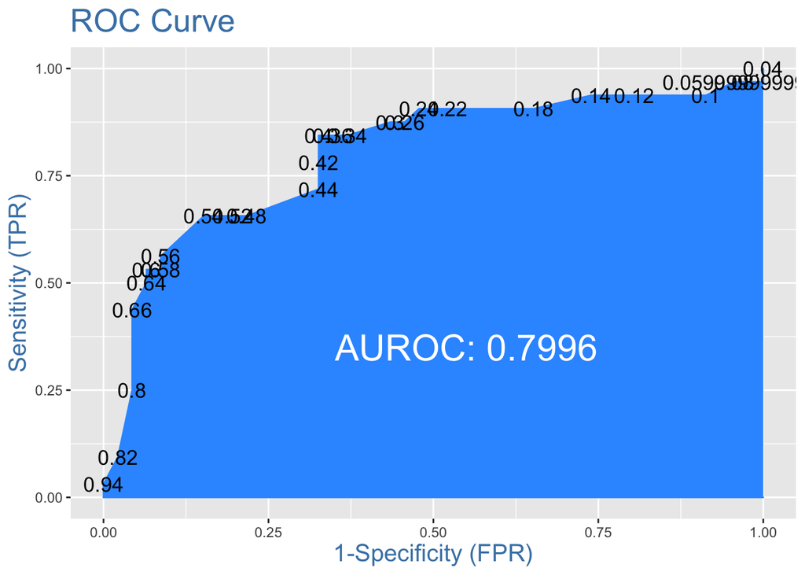

```r
# Curva ROC (Receiver Operating Characteristics): resume el rendimiento del modelo evaluando el trade-off entre la tasa de verdaderos positivos (sensibilidad) y la tasa de falsos positivos (1-especificidad).
InformationValue::plotROC(PREST_HIP$Y, predicted_probs_logit, Show.labels = TRUE) # AUROC: índice de concordancia (entre 0 y 1)
```

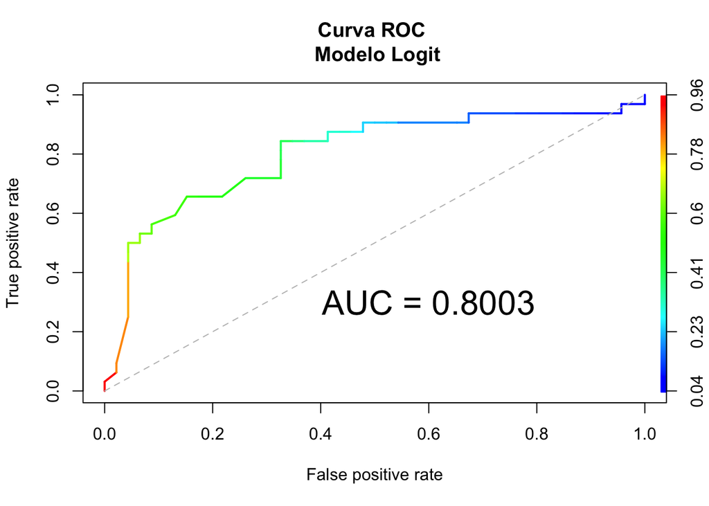

```r
# Con la librería ROCR
pred_logit  <- ROCR::prediction(predictions = predicted_probs_logit, labels = PREST_HIP$Y)
roc_logit   <- ROCR::performance(pred_logit, measure = "tpr", x.measure = "fpr")
auc_logit <- ROCR::performance(pred_logit, measure = "auc")
auc_logit <- unlist(auc_logit@y.values)
#
ROCR::plot(roc_logit, colorize = TRUE, lwd = 2, main = "Curva ROC \n Modelo Logit")
lines(x = c(0, 1), y = c(0, 1), col = "grey", lty = 2)
text(x = 0.6,  y = 0.3, paste0("AUC = ", round(auc_logit, 4)), cex = 2)
```

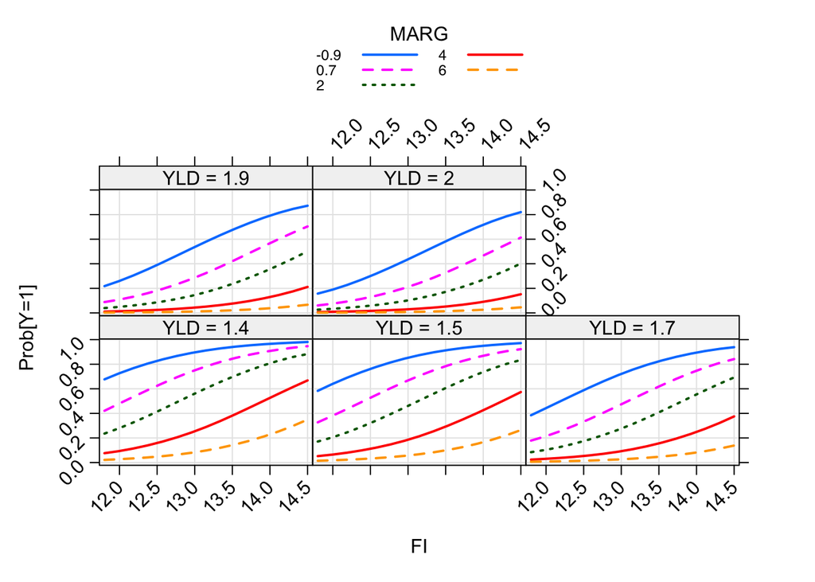

```r
# Gráficas de efectos marginales
# Gráfica conjunta
effs <- Effect(c("FI", "MARG","YLD"), modelo_logit_2)
plot(effs, multiline=TRUE, grid=TRUE, lines=c(1, 2, 3),
     xlab="FI",main="", rotx=45, roty = 45,
     ylab="Prob[Y=1]", rescale.axis=FALSE, rug=FALSE)
```

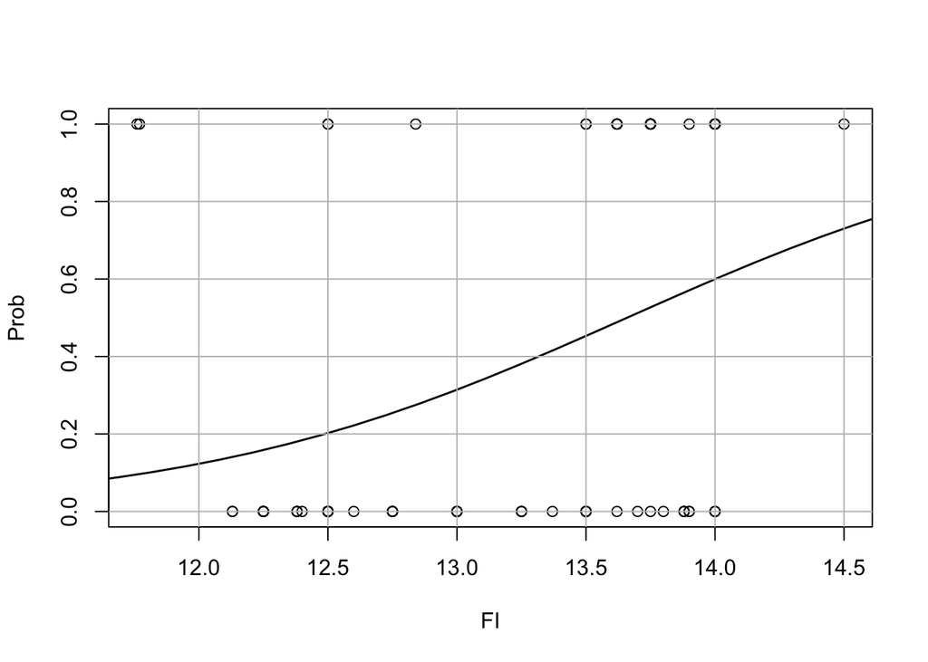

```r
# Gráficas separadas
# Función de probabilidad estimada para la variable FI
#
plot( Y ~ FI, PREST_HIP, xlab="FI", ylab="Prob", ylim=c(0,1))
FInew <- seq(10, 20, length=78)
lines(FInew, predict(modelo_logit_2, newdata=data.frame(FI=FInew, MARG=rep(mean(PREST_HIP$MARG), 78), YLD=rep(mean(PREST_HIP$YLD), 78)), type="response"), lwd=1.5)
grid(col="gray", lty="solid")
```

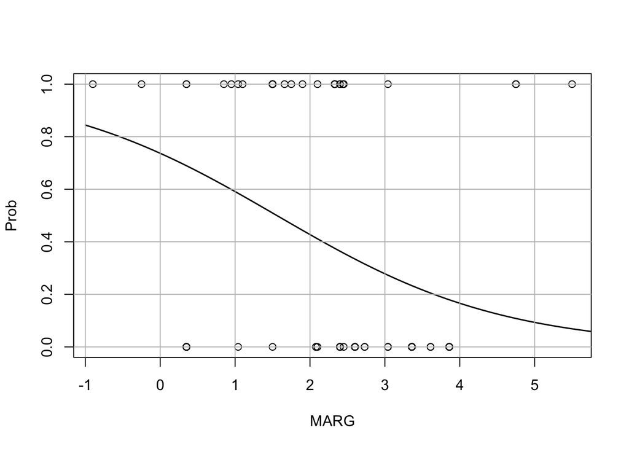

```r
# Función de probabilidad estimada para la variable MARG
plot( Y ~ MARG, PREST_HIP, xlab="MARG", ylab="Prob", ylim=c(0,1))
MARGnew <- seq(-1, 6, length=78)
lines(MARGnew, predict(modelo_logit_2, newdata=data.frame(FI=rep(mean(PREST_HIP$FI), 78), MARG=MARGnew, YLD=rep(mean(PREST_HIP$YLD), 78)), type="response"), lwd=1.5)
grid(col="gray", lty="solid")
```

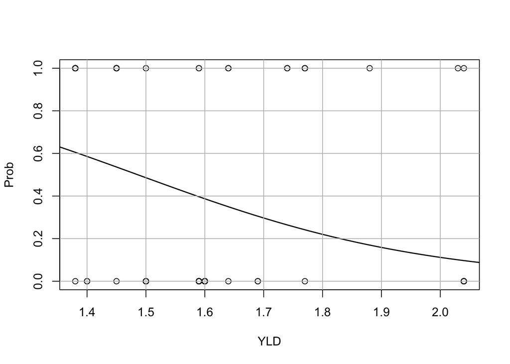

```r
# Función de probabilidad estimada para la variable YLD
plot( Y ~ YLD, PREST_HIP, xlab="YLD", ylab="Prob", ylim=c(0,1))
YLDnew <- seq(1, 2.5, length=78)
lines(YLDnew, predict(modelo_logit_2, newdata=data.frame(FI=rep(mean(PREST_HIP$FI), 78), MARG=rep(mean(PREST_HIP$MARG), 78), YLD=YLDnew), type="response"), lwd=1.5)
grid(col="gray", lty="solid")
```

```r
# Efecto marginal en la media de las variables explicativas
EMM_logit = mfx::logitmfx(formula = modelo_logit_2$formula, data = modelo_logit_2$data, atmean = TRUE)
print(EMM_logit[[1]])
```

```
##           dF/dx  Std. Err.         z       P>|z|
## FI    0.2793924 0.10036058  2.783886 0.005371188
## MARG -0.1558367 0.06775255 -2.300085 0.021443381
## YLD  -0.9505699 0.40847037 -2.327145 0.019957534
```

```r
# Efecto marginal promedio
EMP_logit = mfx::logitmfx(formula = modelo_logit_2$formula, data = modelo_logit_2$data, atmean = FALSE)
print(EMP_logit[[1]])
```

```
##           dF/dx  Std. Err.         z      P>|z|
## FI    0.2137508 0.09751929  2.191883 0.02838798
## MARG -0.1192238 0.06044562 -1.972413 0.04856242
## YLD  -0.7272391 0.36590870 -1.987488 0.04686835
```

```r
# Forma alternativa del EMP
margins(modelo_logit_2)
```

```
##      FI    MARG     YLD
##  0.2138 -0.1192 -0.7272
```

# Código Python

```python
# Lectura de librerías
import numpy as np
import pandas as pd
import matplotlib.pyplot as plt
import statsmodels.formula.api as smf
import statsmodels.api as sm
# Lectura de datos
PREST_HIP = pd.read_csv("PREST_HIP.csv")
PREST_HIP.describe()
# Modelo logit
```

```
##               BA         BS         CB  ...        STL          Y        YLD
## count  78.000000  78.000000  78.000000  ...  78.000000  78.000000  78.000000
## mean   36.038462  16.448718   0.358974  ...  13.422179   0.410256   1.606410
## std     8.052494   3.730003   0.482805  ...  15.230270   0.495064   0.184616
## min    24.000000   6.000000   0.000000  ...   0.000000   0.000000   1.380000
## 25%    31.000000  14.000000   0.000000  ...   3.690000   0.000000   1.450000
## 50%    36.500000  16.000000   0.000000  ...   8.440000   0.000000   1.590000
## 75%    40.500000  18.000000   1.000000  ...  19.435000   1.000000   1.640000
## max    65.000000  25.000000   1.000000  ...  86.350000   1.000000   2.040000
##
## [8 rows x 16 columns]
```

```python
modelo_logit = smf.glm("Y ~ 1 + FI + MARG + YLD", data = PREST_HIP,
family = sm.families.Binomial(link = sm.genmod.families.links.logit())).fit()
print(modelo_logit.summary())
# Formulación alternativa del modelo logit
```

```
##                  Generalized Linear Model Regression Results
## ==============================================================================
## Dep. Variable:                      Y   No. Observations:                   78
## Model:                            GLM   Df Residuals:                       74
## Model Family:                Binomial   Df Model:                            3
## Link Function:                  logit   Scale:                          1.0000
## Method:                          IRLS   Log-Likelihood:                -41.980
## Date:                mar, 28 jun 2022   Deviance:                       83.959
## Time:                        09:17:38   Pearson chi2:                     91.9
## No. Iterations:                     4
## Covariance Type:            nonrobust
## ==============================================================================
##                  coef    std err          z      P>|z|      [0.025      0.975]
## ------------------------------------------------------------------------------
## Intercept     -8.1920      6.881     -1.191      0.234     -21.678       5.294
## FI             1.1846      0.439      2.700      0.007       0.325       2.045
## MARG          -0.6608      0.285     -2.317      0.020      -1.220      -0.102
## YLD           -4.0305      1.713     -2.353      0.019      -7.388      -0.673
## ==============================================================================
```

```python
modelo_logit = smf.logit("Y ~ 1 + FI + MARG + YLD", data = PREST_HIP).fit()
```

```
## Optimization terminated successfully.
##          Current function value: 0.538200
##          Iterations 6
```

```python
print(modelo_logit.summary())
# Modelo probit
```

```
##                            Logit Regression Results
## ==============================================================================
## Dep. Variable:                      Y   No. Observations:                   78
## Model:                          Logit   Df Residuals:                       74
## Method:                           MLE   Df Model:                            3
## Date:                mar, 28 jun 2022   Pseudo R-squ.:                  0.2050
## Time:                        09:17:38   Log-Likelihood:                -41.980
## converged:                       True   LL-Null:                       -52.802
## Covariance Type:            nonrobust   LLR p-value:                 7.731e-05
## ==============================================================================
##                  coef    std err          z      P>|z|      [0.025      0.975]
## ------------------------------------------------------------------------------
## Intercept     -8.1920      6.881     -1.191      0.234     -21.678       5.294
## FI             1.1846      0.439      2.700      0.007       0.325       2.045
## MARG          -0.6608      0.285     -2.317      0.020      -1.220      -0.102
## YLD           -4.0305      1.713     -2.353      0.019      -7.388      -0.673
## ==============================================================================
```

```python
modelo_probit = smf.probit("Y ~ 1 + FI + MARG + YLD", data = PREST_HIP).fit()
```

```
## Optimization terminated successfully.
##          Current function value: 0.542249
##          Iterations 5
```

```python
print(modelo_probit.summary())
# Tabla de éxito-fracaso
```

```
##                           Probit Regression Results
## ==============================================================================
## Dep. Variable:                      Y   No. Observations:                   78
## Model:                         Probit   Df Residuals:                       74
## Method:                           MLE   Df Model:                            3
## Date:                mar, 28 jun 2022   Pseudo R-squ.:                  0.1990
## Time:                        09:17:38   Log-Likelihood:                -42.295
## converged:                       True   LL-Null:                       -52.802
## Covariance Type:            nonrobust   LLR p-value:                 0.0001046
## ==============================================================================
##                  coef    std err          z      P>|z|      [0.025      0.975]
## ------------------------------------------------------------------------------
## Intercept     -4.2090      3.914     -1.075      0.282     -11.881       3.463
## FI             0.6453      0.236      2.740      0.006       0.184       1.107
## MARG          -0.4080      0.163     -2.504      0.012      -0.727      -0.089
## YLD           -2.2888      0.988     -2.318      0.020      -4.224      -0.353
## ==============================================================================
```

```python
tmp_out_1 = modelo_logit.pred_table(threshold = 0.5)
print(pd.DataFrame(tmp_out_1, columns = ["Predichos 0", "Predichos 1"], index = ["Observados 0", "Observados 1"]))
# Formulación alternativa
```

```
##               Predichos 0  Predichos 1
## Observados 0         37.0          9.0
## Observados 1         11.0         21.0
```

```python
from sklearn import metrics
predicted_probs_logit = modelo_logit.predict(exog = PREST_HIP)
tmp_out_2 = metrics.confusion_matrix(modelo_logit.model.endog,
                                   np.where(predicted_probs_logit >= 0.5, 1, 0))
print(pd.DataFrame(tmp_out_2,
                   columns = ["Predichos 0", "Predichos 1"],
                   index = ["Observados 0", "Observados 1"]))
# Precisión global del modelo en términos de predicción
```

```
##               Predichos 0  Predichos 1
## Observados 0           37            9
## Observados 1           11           21
```

```python
tmp_accuracy = metrics.accuracy_score(modelo_logit.model.endog,
                       np.where(predicted_probs_logit >= 0.5, 1, 0))
print(np.round(tmp_accuracy,4))
# Curva ROC
# Definición de la curva ROC
```

```
## 0.7436
```

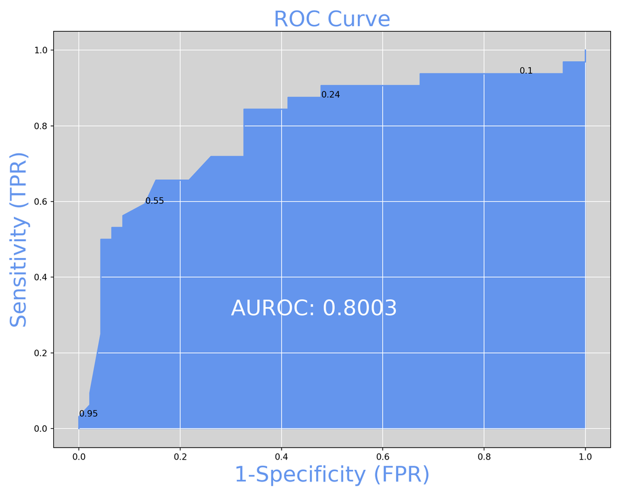

```python
def plotROC(fpr, tpr, thresholds):
  roc_auc = metrics.auc(fpr, tpr)
  fig = plt.figure(figsize = (10, 8))
  plt.plot(fpr, tpr, linestyle = "-", color = "cornflowerblue")
  plt.fill_between(fpr, tpr, 0, color = "cornflowerblue")
  plt.annotate(s = "AUROC: " + str(roc_auc.round(4)), xy = (0.3, 0.3), color = "white", fontsize = 25)
  for i in range(1, len(fpr))[::10]:
    _ = plt.annotate(s = thresholds[i].round(2), xy = (fpr[i], tpr[i]))
  plt.xlabel("1-Specificity (FPR)", color = "cornflowerblue", fontsize = 25)
  plt.ylabel("Sensitivity (TPR)", color = "cornflowerblue", fontsize = 25)
  plt.title("ROC Curve", color = "cornflowerblue", fontsize = 25)
  ax = fig.add_subplot(1, 1, 1)
  ax.set_facecolor("lightgray")
  plt.grid(True, zorder = 0, color = "white")
  plt.rcParams['axes.axisbelow'] = True
  plt.tight_layout()
  plt.show()
# Gráfica
fpr, tpr, thresholds = metrics.roc_curve(PREST_HIP[["Y"]],
                                         predicted_probs_logit, pos_label = 1)
plotROC(fpr, tpr, thresholds)
# Efecto marginal en la media de las variables explicativas
```

```python
EMM_logit = modelo_logit.get_margeff(at = "mean")
print(EMM_logit.summary())
# Efecto marginal promedio
```

```
##         Logit Marginal Effects
## =====================================
## Dep. Variable:                      Y
## Method:                          dydx
## At:                              mean
## ==============================================================================
##                 dy/dx    std err          z      P>|z|      [0.025      0.975]
## ------------------------------------------------------------------------------
## FI             0.2794      0.100      2.784      0.005       0.083       0.476
## MARG          -0.1558      0.068     -2.300      0.021      -0.289      -0.023
## YLD           -0.9506      0.408     -2.327      0.020      -1.751      -0.150
## ==============================================================================
```

```python
EMP_logit = modelo_logit.get_margeff(at = "overall")
print(EMP_logit.summary())
```

```
##         Logit Marginal Effects
## =====================================
## Dep. Variable:                      Y
## Method:                          dydx
## At:                           overall
## ==============================================================================
##                 dy/dx    std err          z      P>|z|      [0.025      0.975]
## ------------------------------------------------------------------------------
## FI             0.2138      0.065      3.274      0.001       0.086       0.342
## MARG          -0.1192      0.045     -2.648      0.008      -0.207      -0.031
## YLD           -0.7272      0.268     -2.719      0.007      -1.252      -0.203
## ==============================================================================
```

# Código Julia

```
## Julia version 1.5.0 at location /Users/JulianRamajo/Library/Application Support/org.R-project.R/R/JuliaCall/julia/v1.5.0/bin will be used.
```

```
## Loading setup script for JuliaCall...
```

```
## Finish loading setup script for JuliaCall.
```

```julia
# Lectura de librerías
using DataFrames, CSV, GLM;
using RegressionTables;
# Lectura de datos
PREST_HIP = CSV.read("PREST_HIP.csv", DataFrame);
describe(PREST_HIP)
```

```
## 16×8 DataFrame. Omitted printing of 1 columns
## │ Row │ variable │ mean     │ min    │ median  │ max   │ nunique │ nmissing │
## │     │ Symbol   │ Float64  │ Real   │ Float64 │ Real  │ Nothing │ Nothing  │
## ├─────┼──────────┼──────────┼────────┼─────────┼───────┼─────────┼──────────┤
## │ 1   │ BA       │ 36.0385  │ 24     │ 36.5    │ 65    │         │          │
## │ 2   │ BS       │ 16.4487  │ 6      │ 16.0    │ 25    │         │          │
## │ 3   │ CB       │ 0.358974 │ 0      │ 0.0     │ 1     │         │          │
## │ 4   │ FI       │ 13.2494  │ 11.76  │ 13.5    │ 14.5  │         │          │
## │ 5   │ FTB      │ 0.615385 │ 0      │ 1.0     │ 1     │         │          │
## │ 6   │ LA       │ 5.68269  │ 0.0    │ 1.355   │ 93.49 │         │          │
## │ 7   │ MARG     │ 2.29192  │ -0.9   │ 2.4     │ 5.5   │         │          │
## │ 8   │ MAT      │ 1.05833  │ 0.42   │ 1.0     │ 2.38  │         │          │
## │ 9   │ MC       │ 0.602564 │ 0      │ 1.0     │ 1     │         │          │
## │ 10  │ MOB      │ 4.20513  │ 1      │ 2.0     │ 28    │         │          │
## │ 11  │ NW       │ 3.50401  │ -0.056 │ 0.7945  │ 17.86 │         │          │
## │ 12  │ PTS      │ 1.49795  │ 0.0    │ 1.66    │ 4.34  │         │          │
## │ 13  │ SE       │ 0.102564 │ 0      │ 0.0     │ 1     │         │          │
## │ 14  │ STL      │ 13.4222  │ 0.0    │ 8.44    │ 86.35 │         │          │
## │ 15  │ Y        │ 0.410256 │ 0      │ 0.0     │ 1     │         │          │
## │ 16  │ YLD      │ 1.60641  │ 1.38   │ 1.59    │ 2.04  │         │          │
```

```julia
# Eodelo logit
modelo_logit = glm(@formula(Y ~ FI + MARG + YLD), PREST_HIP, Binomial(), LogitLink())
```

```
## StatsModels.TableRegressionModel{GeneralizedLinearModel{GLM.GlmResp{Array{Float64,1},Binomial{Float64},LogitLink},GLM.DensePredChol{Float64,Cholesky{Float64,Array{Float64,2}}}},Array{Float64,2}}
##
## Y ~ 1 + FI + MARG + YLD
##
## Coefficients:
## ──────────────────────────────────────────────────────────────────────────
##                  Coef.  Std. Error      z  Pr(>|z|)   Lower 95%  Upper 95%
## ──────────────────────────────────────────────────────────────────────────
## (Intercept)  -8.19199     6.88069   -1.19    0.2338  -21.6779     5.29393
## FI            1.18465     0.438729   2.70    0.0069    0.324755   2.04454
## MARG         -0.660761    0.285158  -2.32    0.0205   -1.21966   -0.101862
## YLD          -4.0305      1.71311   -2.35    0.0186   -7.38814   -0.672856
## ──────────────────────────────────────────────────────────────────────────
```

```julia
regtable(modelo_logit)
```

```
##
## ---------------------
##                  Y
##               -------
##                   (1)
## ---------------------
## (Intercept)    -8.192
##               (6.881)
## FI            1.185**
##               (0.439)
## MARG          -0.661*
##               (0.285)
## YLD           -4.030*
##               (1.713)
## ---------------------
## Estimator          NL
## ---------------------
## N                  78
## R2
## ---------------------
```

```julia
# Modelo probit
modelo_probit = glm(@formula(Y ~ FI + MARG + YLD), PREST_HIP, Binomial(), ProbitLink())
```

```
## StatsModels.TableRegressionModel{GeneralizedLinearModel{GLM.GlmResp{Array{Float64,1},Binomial{Float64},ProbitLink},GLM.DensePredChol{Float64,Cholesky{Float64,Array{Float64,2}}}},Array{Float64,2}}
##
## Y ~ 1 + FI + MARG + YLD
##
## Coefficients:
## ──────────────────────────────────────────────────────────────────────────
##                  Coef.  Std. Error      z  Pr(>|z|)   Lower 95%  Upper 95%
## ──────────────────────────────────────────────────────────────────────────
## (Intercept)  -4.21035     4.00738   -1.05    0.2934  -12.0647     3.64398
## FI            0.645464    0.248784   2.59    0.0095    0.157856   1.13307
## MARG         -0.40793     0.164042  -2.49    0.0129   -0.729447  -0.086414
## YLD          -2.28899     0.994389  -2.30    0.0213   -4.23796   -0.340025
## ──────────────────────────────────────────────────────────────────────────
```

```julia
regtable(modelo_probit)
```

```
##
## ---------------------
##                  Y
##               -------
##                   (1)
## ---------------------
## (Intercept)    -4.210
##               (4.007)
## FI             0.645*
##               (0.249)
## MARG          -0.408*
##               (0.164)
## YLD           -2.289*
##               (0.994)
## ---------------------
## Estimator          NL
## ---------------------
## N                  78
## R2
## ---------------------
```